```python
import pandas as pd
import numpy as np
import re
import matplotlib.pyplot as plt
from sklearn.feature_selection import mutual_info_classif
from sklearn.model_selection import train_test_split
from sklearn.tree import DecisionTreeClassifier
from sklearn import metrics
from sklearn.metrics import plot_confusion_matrix
from sklearn.ensemble import RandomForestClassifier
from sklearn.datasets import make_classification
from sklearn.metrics import confusion_matrix
```

```python
moviesTvshows = pd.read_csv('dataset.csv')
moviesTvshows.head()
```

|  | type | title | cast | country | release_year | listed_in | description |
| --- | --- | --- | --- | --- | --- | --- | --- |
| 0 | Movie | Dick Johnson Is Dead | NaN | United States | 2020 | Documentaries | As her father nears the end of his life, filmm... |
| 1 | TV Show | Blood & Water | Ama Qamata, Khosi Ngema, Gail Mabalane, Thaban... | South Africa | 2021 | International TV Shows, TV Dramas, TV Mysteries | After crossing paths at a party, a Cape Town t... |
| 2 | TV Show | Ganglands | Sami Bouajila, Tracy Gotoas, Samuel Jouy, Nabi... | NaN | 2021 | Crime TV Shows, International TV Shows, TV Act... | To protect his family from a powerful drug lor... |
| 3 | TV Show | Jailbirds New Orleans | NaN | NaN | 2021 | Docuseries, Reality TV | Feuds, flirtations and toilet talk go down amo... |
| 4 | TV Show | Kota Factory | Mayur More, Jitendra Kumar, Ranjan Raj, Alam K... | India | 2021 | International TV Shows, Romantic TV Shows, TV ... | In a city of coaching centers known to train I... |

فاز صفر

1

```python
moviesTvshows.info()
```

```
<class 'pandas.core.frame.DataFrame'>
RangeIndex: 11059 entries, 0 to 11058
Data columns (total 7 columns):
 #   Column        Non-Null Count  Dtype
---  ------        --------------  -----
 0   type          11059 non-null  object
 1   title         11059 non-null  object
 2   cast          9694 non-null   object
 3   country       8364 non-null   object
 4   release_year  11059 non-null  int64
 5   listed_in     11059 non-null  object
 6   description   11059 non-null  object
dtypes: int64(1), object(6)
memory usage: 604.9+ KB
```

```python
moviesTvshows.describe()
```

|  | release_year |
| --- | --- |
| count | 11059.000000 |
| mean | 2014.209603 |
| std | 8.959517 |
| min | 1925.000000 |
| 25% | 2013.000000 |
| 50% | 2017.000000 |
| 75% | 2019.000000 |
| max | 2021.000000 |

2

```python
percent_missing = moviesTvshows.isnull().sum() * 100 / len(moviesTvshows)
missing_value_df = pd.DataFrame({'percent_missing': percent_missing})
missing_value_df
```

|  | percent_missing |
| --- | --- |
| type | 0.000000 |
| title | 0.000000 |
| cast | 12.342888 |
| country | 24.369292 |
| release_year | 0.000000 |
| listed_in | 0.000000 |
| description | 0.000000 |

فاز یک

1

میشود آن سطر ها را حذف کرد یا میتوان آن هارا با

mode

جایگزین کنیم .

```python
for i in range (0, len(moviesTvshows.columns)):
    moviesTvshows.iloc[:, i].fillna(moviesTvshows.iloc[:, i].mode()[0], inplace=True)
```

```python
moviesTvshows.info()
```

```
<class 'pandas.core.frame.DataFrame'>
RangeIndex: 11059 entries, 0 to 11058
Data columns (total 7 columns):
 #   Column        Non-Null Count  Dtype
---  ------        --------------  -----
 0   type          11059 non-null  object
 1   title         11059 non-null  object
 2   cast          11059 non-null  object
 3   country       11059 non-null  object
 4   release_year  11059 non-null  int64
 5   listed_in     11059 non-null  object
 6   description   11059 non-null  object
dtypes: int64(1), object(6)
memory usage: 604.9+ KB
```

**2**

normalization: دیتا پیوسته عددی رو جوری اسکیل کنیم که بین صفر و یک باشند

standardization: دیتا پیوسته عددی رو جوری اسکیل کنیم که میانگین اش صفر باشد وانحراف معیارش یک باشد از هیچ کدام استفاده نمیکنیم چون

tree based

هستند.

**3**

lable encoding: برایشان معادل عددی برای هر دسته قرار میدهد

one hot encoding: هر دسته را تبدیل به یک فیچر میکند و با توجه به اینکه اون سطر این فیچر را دارد یا خیر صفر یا یک جایگرین میکند

از روش

lable encoding

استفاده کردم چون در وان هات اگر تعداد دسته ها زیاد باشد، زیادی بزرگ میشود.

```python
from sklearn import preprocessing

label_encoder = preprocessing.LabelEncoder()
moviesTvshows.iloc[:,0] = label_encoder.fit_transform(moviesTvshows.iloc[:,0])
```

```python
moviesTvshows.head()
```

|  | type | title | cast | country | release_year | listed_in | description |
| --- | --- | --- | --- | --- | --- | --- | --- |
| 0 | 0 | Dick Johnson Is Dead | David Attenborough | United States | 2020 | Documentaries | As her father nears the end of his life, filmm... |
| 1 | 1 | Blood & Water | Ama Qamata, Khosi Ngema, Gail Mabalane, Thaban... | South Africa | 2021 | International TV Shows, TV Dramas, TV Mysteries | After crossing paths at a party, a Cape Town t... |
| 2 | 1 | Ganglands | Sami Bouajila, Tracy Gotoas, Samuel Jouy, Nabi... | United States | 2021 | Crime TV Shows, International TV Shows, TV Act... | To protect his family from a powerful drug lor... |
| 3 | 1 | Jailbirds New Orleans | David Attenborough | United States | 2021 | Docuseries, Reality TV | Feuds, flirtations and toilet talk go down amo... |
| 4 | 1 | Kota Factory | Mayur More, Jitendra Kumar, Ranjan Raj, Alam K... | India | 2021 | International TV Shows, Romantic TV Shows, TV ... | In a city of coaching centers known to train I... |

**4**

ستون لیستد این را به سه ستون ژانر تبدیل کردیم و آن هایی که سه ژانر نداشتند مقدار نال گرفتند

روش دیگر هم اینکه میتوانیم برای هر مقداری یک سطر جدا به دیتا ست اضافه کنیم.

```python
moviesTvshows['genre1'] = moviesTvshows['listed_in'].str.split(',', 2, expand = True)[0]
moviesTvshows['genre2'] = moviesTvshows['listed_in'].str.split(',', 2, expand = True)[1]
moviesTvshows['genre3'] = moviesTvshows['listed_in'].str.split(',', 2, expand = True)[2]
moviesTvshows.drop(['listed_in'], axis = 1, inplace = True)
moviesTvshows.head()
```

|  | type | title | cast | country | release_year | description | genre1 | genre2 | genre3 |
| --- | --- | --- | --- | --- | --- | --- | --- | --- | --- |
| 0 | 0 | Dick Johnson Is Dead | David Attenborough | United States | 2020 | As her father nears the end of his life, filmm... | Documentaries | None | None |
| 1 | 1 | Blood & Water | Ama Qamata, Khosi Ngema, Gail Mabalane, Thaban... | South Africa | 2021 | After crossing paths at a party, a Cape Town t... | International TV Shows | TV Dramas | TV Mysteries |
| 2 | 1 | Ganglands | Sami Bouajila, Tracy Gotoas, Samuel Jouy, Nabi... | United States | 2021 | To protect his family from a powerful drug lor... | Crime TV Shows | International TV Shows | TV Action & Adventure |
| 3 | 1 | Jailbirds New Orleans | David Attenborough | United States | 2021 | Feuds, flirtations and toilet talk go down amo... | Docuseries | Reality TV | None |
| 4 | 1 | Kota Factory | Mayur More, Jitendra Kumar, Ranjan Raj, Alam K... | India | 2021 | In a city of coaching centers known to train I... | International TV Shows | Romantic TV Shows | TV Comedies |

```python
moviesTvshows.iloc[:,3] = label_encoder.fit_transform(moviesTvshows.iloc[:,3])
moviesTvshows.iloc[:,4] = label_encoder.fit_transform(moviesTvshows.iloc[:,4])
moviesTvshows.iloc[:,6] = label_encoder.fit_transform(moviesTvshows.iloc[:,6])
moviesTvshows.iloc[:,7] = label_encoder.fit_transform(moviesTvshows.iloc[:,7])
moviesTvshows.iloc[:,8] = label_encoder.fit_transform(moviesTvshows.iloc[:,8])
```

```python
moviesTvshows.head()
```

|  | type | title | cast | country | release_year | description | genre1 | genre2 | genre3 |
| --- | --- | --- | --- | --- | --- | --- | --- | --- | --- |
| 0 | 0 | Dick Johnson Is Dead | David Attenborough | 608 | 74 | As her father nears the end of his life, filmm... | 22 | 75 | 90 |
| 1 | 1 | Blood & Water | Ama Qamata, Khosi Ngema, Gail Mabalane, Thaban... | 430 | 75 | After crossing paths at a party, a Cape Town t... | 37 | 63 | 66 |
| 2 | 1 | Ganglands | Sami Bouajila, Tracy Gotoas, Samuel Jouy, Nabi... | 608 | 75 | To protect his family from a powerful drug lor... | 20 | 33 | 62 |
| 3 | 1 | Jailbirds New Orleans | David Attenborough | 608 | 75 | Feuds, flirtations and toilet talk go down amo... | 24 | 46 | 90 |
| 4 | 1 | Kota Factory | Mayur More, Jitendra Kumar, Ranjan Raj, Alam K... | 254 | 75 | In a city of coaching centers known to train I... | 37 | 49 | 63 |

با استفاده از

tf-idf

که در آن لزوما تکرار بالای یک کلمه ارزش ان را زیاد نمیکند

```python
from sklearn.feature_extraction.text import (CountVectorizer,
                                             TfidfVectorizer,
                                             TfidfTransformer)

vectorizer = CountVectorizer(analyzer='word',
                              token_pattern=r'\b[a-zA-Z]{3,}\b',
                              ngram_range=(1, 1) , min_df = 10
                              )
mergeDesTitle = moviesTvshows['description'] + moviesTvshows['title']
count_vectorized = vectorizer.fit_transform(mergeDesTitle)
tfidf_transformer = TfidfTransformer(smooth_idf=True, use_idf=True)
vectorized = tfidf_transformer.fit_transform(count_vectorized)

desTitle = pd.DataFrame(vectorized.toarray(),
             index=['sentence '+str(i)
                    for i in range(1, 1+len(mergeDesTitle))],
             columns=vectorizer.get_feature_names())

desTitleFeatures = []
for i in range(len(desTitle.columns)):
    maxVal = desTitle.iloc[:, i].max()
    if (maxVal > 0.735):
        if (desTitle.iloc[0, i] not in desTitleFeatures):
            desTitleFeatures.append(desTitle.columns[i])
desTitle.loc[:, desTitleFeatures]

feature_df = moviesTvshows.copy()
feature_df.drop(['description', 'title','cast'], axis = 1, inplace = True)
feature_df = feature_df.join(desTitle.loc[:, desTitleFeatures].reset_index(drop = True))
feature_df.head()
```

|  | type | country | release_year | genre1 | genre2 | genre3 | act | adventures | agent | amazon | ... | sheep | short | spider | sugar | test | toys | train | transported | trucks | zoo |
| --- | --- | --- | --- | --- | --- | --- | --- | --- | --- | --- | --- | --- | --- | --- | --- | --- | --- | --- | --- | --- | --- |
| 0 | 0 | 608 | 74 | 22 | 75 | 90 | 0.0 | 0.0 | 0.0 | 0.0 | ... | 0.0 | 0.0 | 0.0 | 0.0 | 0.0 | 0.0 | 0.000000 | 0.0 | 0.0 | 0.0 |
| 1 | 1 | 430 | 75 | 37 | 63 | 66 | 0.0 | 0.0 | 0.0 | 0.0 | ... | 0.0 | 0.0 | 0.0 | 0.0 | 0.0 | 0.0 | 0.000000 | 0.0 | 0.0 | 0.0 |
| 2 | 1 | 608 | 75 | 20 | 33 | 62 | 0.0 | 0.0 | 0.0 | 0.0 | ... | 0.0 | 0.0 | 0.0 | 0.0 | 0.0 | 0.0 | 0.000000 | 0.0 | 0.0 | 0.0 |
| 3 | 1 | 608 | 75 | 24 | 46 | 90 | 0.0 | 0.0 | 0.0 | 0.0 | ... | 0.0 | 0.0 | 0.0 | 0.0 | 0.0 | 0.0 | 0.000000 | 0.0 | 0.0 | 0.0 |
| 4 | 1 | 254 | 75 | 37 | 49 | 63 | 0.0 | 0.0 | 0.0 | 0.0 | ... | 0.0 | 0.0 | 0.0 | 0.0 | 0.0 | 0.0 | 0.277893 | 0.0 | 0.0 | 0.0 |

5 rows × 56 columns

با استفاده از

count vectorize

که اگر آن کلمه در آن سطر وجود داشته باشد ستون متناظرش را یک قرار میدهد.

```python
vectorizer = CountVectorizer(analyzer='word',
                              token_pattern=r'\b[a-zA-Z]{3,}\b',
                              ngram_range=(2, 2), min_df = 10 , max_features = 10 )
vectorized = vectorizer.fit_transform(moviesTvshows['cast'])
actors = pd.DataFrame(vectorized.toarray(),
             index=['sentence '+str(i)
                    for i in range(1, 1+len(moviesTvshows['cast']))],
             columns=vectorizer.get_feature_names())
actors
feature_df = feature_df.join(actors.reset_index(drop = True))
feature_df.head()
```

|  | type | country | release_year | genre1 | genre2 | genre3 | act | adventures | agent | amazon | ... | anupam kher | david attenborough | juan pablo | julie tejwani | naseeruddin shah | rukh khan | rupa bhimani | shah rukh | takahiro sakurai | yuki kaji |
| --- | --- | --- | --- | --- | --- | --- | --- | --- | --- | --- | --- | --- | --- | --- | --- | --- | --- | --- | --- | --- | --- |
| 0 | 0 | 608 | 74 | 22 | 75 | 90 | 0.0 | 0.0 | 0.0 | 0.0 | ... | 0 | 1 | 0 | 0 | 0 | 0 | 0 | 0 | 0 | 0 |
| 1 | 1 | 430 | 75 | 37 | 63 | 66 | 0.0 | 0.0 | 0.0 | 0.0 | ... | 0 | 0 | 0 | 0 | 0 | 0 | 0 | 0 | 0 | 0 |
| 2 | 1 | 608 | 75 | 20 | 33 | 62 | 0.0 | 0.0 | 0.0 | 0.0 | ... | 0 | 0 | 0 | 0 | 0 | 0 | 0 | 0 | 0 | 0 |
| 3 | 1 | 608 | 75 | 24 | 46 | 90 | 0.0 | 0.0 | 0.0 | 0.0 | ... | 0 | 1 | 0 | 0 | 0 | 0 | 0 | 0 | 0 | 0 |
| 4 | 1 | 254 | 75 | 37 | 49 | 63 | 0.0 | 0.0 | 0.0 | 0.0 | ... | 0 | 0 | 0 | 0 | 0 | 0 | 0 | 0 | 0 | 0 |

5 rows × 66 columns

بررسی روابط بین ویژگی ها

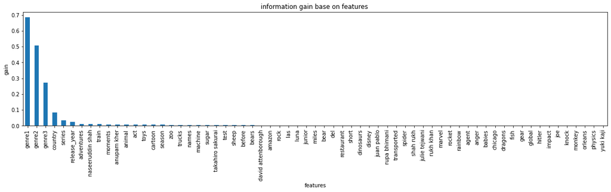

```python
target = feature_df['type']
# infoGain = mutual_info_classif(feature_df, target)
infoGain = pd.Series(mutual_info_classif(feature_df.iloc[:,1:], target))
infoGain.index = feature_df.columns[1:]
infoGain.sort_values(ascending=False).plot.bar(figsize=(20, 4))
plt.title('information gain base on features ')
plt.xlabel('features')
plt.ylabel('gain');
```

همنطور که مشخص است ژانر یک از همه بهتر است و به ترتیب بعد از آن ژانر 2و 3 و کشور ویژگی های بهتری هستند.

فاز دوم

```python
def fineBestHyper(target):
    X_train, X_test, y_train, y_test = train_test_split(feature_df.iloc[:, 1:], target, test_size = 0.3, random_state = 1)
    clf = GridSearchCV(DecisionTreeClassifier(),
                      {'min_samples_split': np.arange(2, 3, 4),
                      'max_depth':[5, 10, 20, 30, 40, 50]},
                      cv = 4, return_train_score = False, scoring = 'accuracy')
    clf = clf.fit(X_train,y_train)
    pd.DataFrame(clf.cv_results_).head(10)
    accuracy = clf.best_score_
    print(accuracy)
    print (clf.best_params_)
fineBestHyper(feature_df[['type']])
```

```
0.9931539229504345
{'max_depth': 40, 'min_samples_split': 2}
```

```python
x = feature_df.iloc[:, 1:]
y = feature_df[['type']]
X_train, X_test, y_train, y_test = train_test_split(x, y, test_size = 0.3, random_state = 1)
clf = DecisionTreeClassifier()
clf = clf.fit(X_train,y_train)
y_pred = clf.predict(X_test)
ytrain_pred = clf.predict(X_train)
print("Accuracy:",metrics.accuracy_score(y_test, y_pred))
print("Accuracy:",metrics.accuracy_score(y_train, ytrain_pred))
```

```
Accuracy: 0.995177817962628
Accuracy: 1.0
```

داده ها به نسبت 70 به 30 به ترین و تست تقسیم بندی شده اند و چون مدل بر اساس داده ترین است و خیلی خوب فیت شده است اکیوریسی تایپ پیش بینی شده برای آن یک است

```python
print(confusion_matrix(y_test, y_pred))
print(confusion_matrix(y_train, ytrain_pred))
```

```
[[1796   10]
 [   6 1506]]
[[4325    0]
 [   0 3416]]
```

برای نسبت سایز 70 به 30 تخمین داده ی تست 1796+1506 تا درست تشخیص داده شده است و 6+10 تا اشتباه و برای داده ترین همه درست تشخیص داده شده اند.

```python
X_train, X_test, y_train, y_test = train_test_split(x, y, test_size = 0.02, random_state = 1)
clf = clf.fit(X_train,y_train)
ytrain_pred = clf.predict(X_train)
y_pred = clf.predict(X_test)
print("Accuracy:",metrics.accuracy_score(y_test, y_pred))
print("Accuracy:",metrics.accuracy_score(y_train, ytrain_pred))
```

```
Accuracy: 0.9864864864864865
Accuracy: 1.0
```

داده ها به نسبت 98 به 2 به ترین و تست تقسیم بندی شده اند و میدانیم این کار میتواند منجر به

overfitting

شود. اما اینجا این اتفاق نیافتاده است زیرا همچنین دقت مان بالاست.

```python
print(confusion_matrix(y_test, y_pred))
print(confusion_matrix(y_train, ytrain_pred))
```

```
[[122   1]
 [  2  97]]
[[6008    0]
 [   0 4829]]
```

```python
X_train, X_test, y_train, y_test = train_test_split(x, y, test_size = 0.9, random_state = 1)
clf = clf.fit(X_train,y_train)
ytrain_pred = clf.predict(X_train)
y_pred = clf.predict(X_test)
print("Accuracy:",metrics.accuracy_score(y_test, y_pred))
print("Accuracy:",metrics.accuracy_score(y_train, ytrain_pred))
```

```
Accuracy: 0.977195097448262
Accuracy: 1.0
```

داده ها به نسبت 10 به 90 به ترین و تست تقسیم بندی شده اند و میدانیم این کار میتواند منجر به

underfitting

شود. اما اینجا این اتفاق نیافتاده است زیرا همچنین دقت مان بالاست.

```python
print(confusion_matrix(y_test, y_pred))
print(confusion_matrix(y_train, ytrain_pred))
```

```
[[5445   96]
 [ 131 4282]]
[[590   0]
 [  0 515]]
```

**2**

Max depth: حداکثر عمق درخت را نشان میدهد.

Min sample split: تعداد نمونه هایی که نیاز داریم تا یک نود داخلی درخت بتواند به زیر شاخه ها تقسیم شود. این مقدار به صورت پیش فرض برابر ۲ است.

```python
X_train, X_test, y_train, y_test = train_test_split(x, y, test_size = 0.3, random_state = 1)
clf = clf.fit(X_train,y_train)
maxDepth = [3, 7, 12, 15, 17, 30, 40, 50]
accuListTest = list()
accuListTrain = list()
for m in maxDepth:
    clf = DecisionTreeClassifier(max_depth = m)
    clf = clf.fit(X_train,y_train)
    ytrain_pred = clf.predict(X_train)
    y_pred = clf.predict(X_test)
    accuListTest.append (metrics.accuracy_score(y_test, y_pred))
    accuListTrain.append (metrics.accuracy_score(y_train, ytrain_pred))
    print("Max depth is ", m ,"and Accuracy:",metrics.accuracy_score(y_test, y_pred))
    print("Max depth is ", m ,"and Accuracy:",metrics.accuracy_score(y_train, ytrain_pred))
    print("________________")
```

```
Max depth is  3 and Accuracy: 0.8004822182037372
Max depth is  3 and Accuracy: 0.8146234336649012
________________
Max depth is  7 and Accuracy: 0.9526823387582881
Max depth is  7 and Accuracy: 0.9460018085518667
________________
Max depth is  12 and Accuracy: 0.9945750452079566
Max depth is  12 and Accuracy: 0.9996124531714249
________________
Max depth is  15 and Accuracy: 0.9945750452079566
Max depth is  15 and Accuracy: 1.0
________________
Max depth is  17 and Accuracy: 0.995177817962628
Max depth is  17 and Accuracy: 1.0
________________
Max depth is  30 and Accuracy: 0.9948764315852924
Max depth is  30 and Accuracy: 1.0
________________
Max depth is  40 and Accuracy: 0.995177817962628
Max depth is  40 and Accuracy: 1.0
________________
Max depth is  50 and Accuracy: 0.995177817962628
Max depth is  50 and Accuracy: 1.0
________________
```

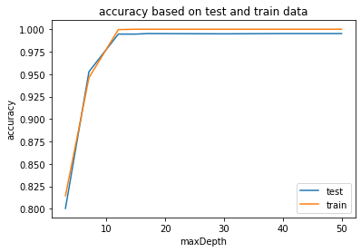

```python
plt.plot(maxDepth, accuListTest)
plt.plot(maxDepth, accuListTrain)
plt.legend(['test', 'train'])
plt.xlabel('maxDepth')
plt.ylabel('accuracy')
plt.title('accuracy based on test and train data');
```

```python
maxDepth = [3, 12, 40]
for m in maxDepth:
    clf = DecisionTreeClassifier(max_depth = m)
    clf = clf.fit(X_train,y_train)
    ytrain_pred = clf.predict(X_train)
    y_pred = clf.predict(X_test)
    print(confusion_matrix(y_test, y_pred))
    print(confusion_matrix(y_train, ytrain_pred))
    print('------------')
```

```
[[1319  487]
 [ 175 1337]]
[[3248 1077]
 [ 358 3058]]
------------
[[1795   11]
 [   6 1506]]
[[4324    1]
 [   2 3414]]
------------
[[1795   11]
 [   6 1506]]
[[4325    0]
 [   0 3416]]
------------
```

فاز سوم

```python
X_train, X_test, y_train, y_test = train_test_split(x, y, test_size = 0.3, random_state = 1)
clf = RandomForestClassifier( random_state=1)
clf = clf.fit(X_train,y_train)
y_pred = clf.predict(X_test)
print("Accuracy:",metrics.accuracy_score(y_test, y_pred))
```

```
Accuracy: 0.9849306811332128
```

واریانس در یک مدل تجمیعی بهتر عمل میکند اما بایاس تفاوتی نمیکند در هرحال در اینجا چون اکیوریسی بالاست این تفاوت مشهود نیست.